# Case Study 1: HeLa Cell Cycling

Antoine Bodein

CHU de Québec Research Center, Université Laval, Molecular Medicine department, Québec, QC, Canada

antoine.bodein.1@ulaval.ca

15 October 2021

# Contents

```r
library(tidyverse)
library(mixOmics)
library(timeOmics)
library(igraph)
library(minet)
library(gprofiler2)
library(RandomWalkRestartMH)
library(GO.db)
library(ComplexHeatmap)
library(org.Hs.eg.db)
```

```r
source("./CS1_utils.R")
```

# 1 Preprocessing

We get raw data from (Aviner et al. 2015).

Multi-omics data is composed of:

- mRNA
- Translation Data (iBAQ and LFQ normalisation)
- Proteomics (iBAQ and LFQ normalisation)

For Translation and Proteomics, we selected iBAQ normalisation.

```r
all_data <- openxlsx::read.xlsx("data/pgen.1005554.s012.xlsx", startRow = 2)

# ID conversion from uniprot retriver
conv <- read_tsv("./data/uniprot_mapping.tab") %>% unique

type <- c("Translation.(LFQ)", "Translation.(iBAQ)", "Protein.(iBAQ)",
          "Protein.(LFQ)", "mRNA")
DATA <- purrr::map(type, ~{all_data %>%
        dplyr::select(Leading.Uniprot.IDs, contains(.x))}) %>%
    purrr::map(~ .x %>% as_tibble %>%
                   column_to_rownames("Leading.Uniprot.IDs") %>% t
               %>% as.data.frame(stringsAsFactor = FALSE))
names(DATA) <- type

DATA <- lapply(DATA,
               function(x) `rownames<-`(x,rownames(x) %>% str_remove(".*\\.")))

mRNA <- DATA$mRNA %>% t %>% as.data.frame %>% na.omit() %>%
    t %>% as.data.frame()

trans <- lapply(DATA$`Translation.(iBAQ)`, function(x)
    as.character(x) %>% as.numeric) %>%
    as.data.frame(row.names =  rownames(DATA$`Translation.(iBAQ)`)) %>%
    t %>% as.data.frame %>% na.omit() %>% t %>% as.data.frame()

protein <- lapply(DATA$`Protein.(iBAQ)`, function(x)
    as.character(x) %>% as.numeric) %>%
    as.data.frame(row.names =  rownames(DATA$`Protein.(iBAQ)`)) %>%
    t %>% as.data.frame %>% na.omit() %>% t %>% as.data.frame()

save(mRNA, trans, protein, file = "./result/norm_data.rda")
```

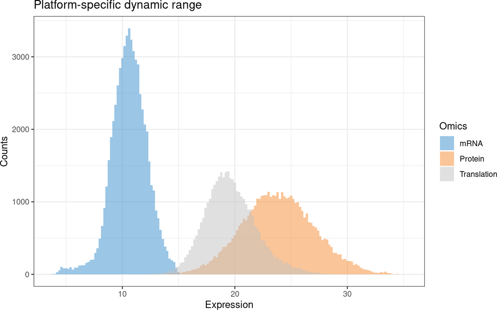

```r
tmp_data = list("mRNA" = mRNA, "Translation" = trans, "Protein" = protein) %>%
imap_dfr( ~{
    .x %>% rownames_to_column("sample") %>%
        gather(molecule, value, -sample) %>%
        mutate(Omics = .y)
})
ggplot(tmp_data, aes(x=value, fill=Omics)) +
    geom_histogram(binwidth=.2, alpha=.5, position="identity")+
    scale_fill_manual(values = mixOmics::color.mixo(1:3)) +
    theme_bw() +
    ggtitle("Platform-specific dynamic range") + xlab("Expression") + ylab("Counts")
```

The filtering step, threshold:

- mRNA: log(2)
- trans: log(3)
- proteins: log(3)

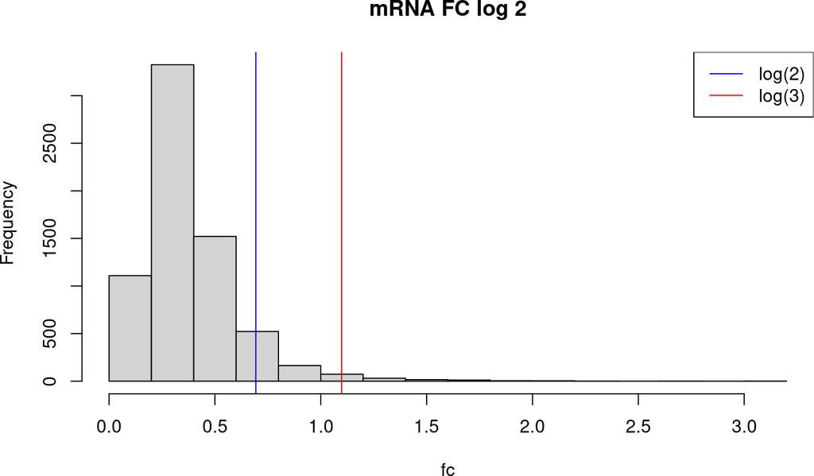

```r
mRNA.fc <- remove.fold.change(mRNA, log(2),
                              hist.title = "mRNA FC log 2", plot = TRUE)
```

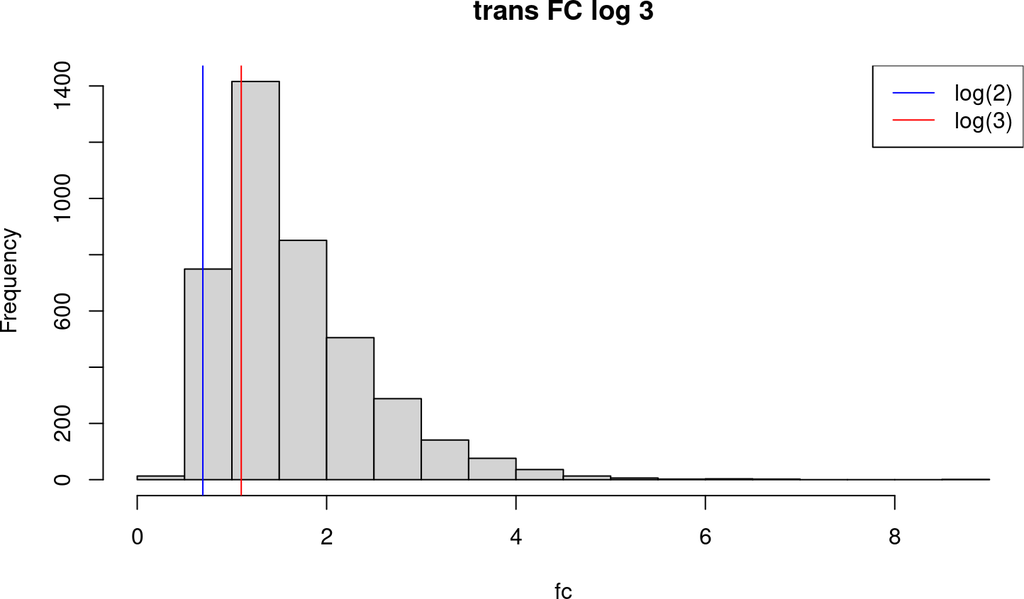

```r
# Uniprot ID conversion to gene SYMBOL
mRNA.fc <- mRNA.fc %>% rownames_to_column("sample") %>%
    gather(molecule, value, -sample) %>%
    left_join(conv, by = c("molecule"="UNIPROT")) %>% na.omit %>%
    dplyr::select(sample, SYMBOL, value) %>%
    group_by(sample, SYMBOL) %>%
    summarise(value = mean(value)) %>%
    spread(SYMBOL, value) %>%
    column_to_rownames("sample")

trans.fc <- remove.fold.change(trans, log(3),
                               hist.title = "trans FC log 3", plot = TRUE)
```

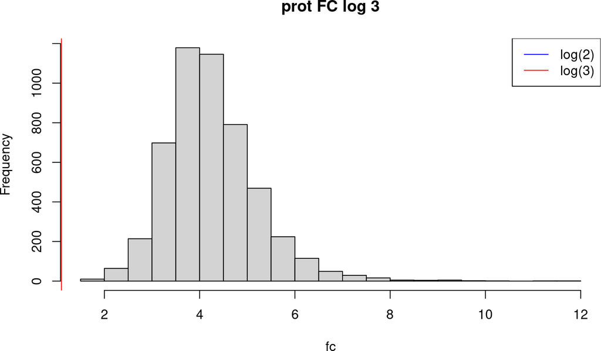

```r
trans.fc <- trans.fc %>% rownames_to_column("sample") %>%
    gather(molecule, value, -sample) %>%
    filter(molecule %in% conv$UNIPROT) %>%
    dplyr::select(sample, molecule, value) %>% spread(molecule, value) %>%
    column_to_rownames("sample")

prot.fc <- remove.fold.change(protein, log(3),
                              hist.title = "prot FC log 3", plot = TRUE)
```

```r
prot.fc <- prot.fc %>% rownames_to_column("sample") %>%
    gather(molecule, value, -sample) %>%
    filter(molecule %in% conv$UNIPROT) %>%
    dplyr::select(sample, molecule, value) %>%
    spread(molecule, value) %>%
column_to_rownames("sample")

colnames(mRNA.fc) <- paste0("mRNA_", colnames(mRNA.fc))
colnames(trans.fc) <- paste0("trans_", colnames(trans.fc))
colnames(prot.fc) <- paste0("prot_", colnames(prot.fc))
```

```r
# modeling
# median value
mRNA.fc %>% rownames_to_column("sample") %>%
    mutate(group = sample %>% str_remove("_.*")) %>%
    gather(feature, value, -c(sample, group)) %>%
    group_by(group, feature) %>%
    summarise(Value = median(value)) %>%
#    summarise(Value = mean(value)) %>%
    spread(feature, Value) %>%
    as.data.frame() %>%
    column_to_rownames("group") -> mRNA.modelled
mRNA.modelled <- mRNA.modelled[c("G1", "S", "G2/M"),]


trans.fc %>% rownames_to_column("sample") %>% mutate(group = sample %>% str_remove("_.*")) %>%
    gather(feature, value, -c(sample, group)) %>%
    group_by(group, feature) %>%
    summarise(Value = median(value)) %>%
#    summarise(Value = mean(value)) %>%
    spread(feature, Value) %>%
    as.data.frame() %>%
    column_to_rownames("group") -> trans.modelled
trans.modelled <- trans.modelled[c("G1", "S", "G2/M"),]


prot.fc %>% rownames_to_column("sample") %>% mutate(group = sample %>% str_remove("_.*")) %>%
    gather(feature, value, -c(sample, group)) %>%
    group_by(group, feature) %>%
    summarise(Value = median(value)) %>%
#    summarise(Value = mean(value)) %>%
    spread(feature, Value) %>%
    as.data.frame() %>%
    column_to_rownames("group") -> prot.modelled
prot.modelled <- prot.modelled[c("G1", "S", "G2/M"),]


save(mRNA.fc, prot.fc, trans.fc, mRNA.modelled, trans.modelled, prot.modelled, file = "./result/modelled_data.rda")
```

# 2 Modelling

Because there were only 3 timepoints (3 replicates), we tested 2 different way of modelling (median and LMMS).

```r
time <- rownames(mRNA.fc) %>% str_remove("_.*") %>%
    factor(levels = c("G1","S","G2/M")) %>% as.numeric

lmms.output <- lmms::lmmSpline(data = mRNA.fc, time = time,
                               sampleID = rownames(mRNA.fc), deri = FALSE,
                               basis = "cubic p-spline",
                               numCores = 4, timePredict = 1:3,
                               keepModels = TRUE)
modelled.data <- t(slot(lmms.output, 'predSpline'))

lmms.mRNA <- wrapper.lmms(mRNA.fc, time, sampleID = rownames(mRNA.fc))
lmms.mRNA$summary
```

```
##                0   1
## pspline       60 388
## cubic.pspline 60 388
```

```r
mRNA.filter <- lmms.filter.lines(data = mRNA.fc,
                                lmms.obj = lmms.mRNA$pspline, time = time) %>%
    .$filtered

lmms.trans <- wrapper.lmms(trans.fc, time, sampleID = rownames(trans.fc))
lmms.trans$summary
```

```
##                  0   1
## pspline       2414 258
## cubic.pspline 2414 258
```

```r
trans.filter <- lmms.filter.lines(data = trans.fc,
                                 lmms.obj = lmms.trans$pspline, time = time) %>%
    .$filtered

lmms.prot <- wrapper.lmms(prot.fc, time, sampleID = rownames(prot.fc))
lmms.prot$summary
```

```
##                 0    1
## pspline       272 4023
## cubic.pspline 272 4023
```

```r
prot.filter <- lmms.filter.lines(data = prot.fc,
                                  lmms.obj = lmms.prot$pspline, time = time) %>%
    .$filtered

# remove from fc (filtering step)
mRNA.fc <- dplyr::select(mRNA.fc, colnames(mRNA.filter))
trans.fc <- dplyr::select(trans.fc, colnames(trans.filter))
prot.fc <- dplyr::select(prot.fc, colnames(prot.filter))

save(mRNA.fc, prot.fc, trans.fc, mRNA.filter, trans.filter, prot.filter,
     file = "./result/data_filtered.rda")
```

# 3 Clustering

We tested 2 different clustering:

- timeOmics (with a block PLS).
- sign of variation (Up Down) as described in the paper

We tested the 2 clustering approaches on the 2 modeling approaches.

First with timeOmics:

```r
data.mean <- list("mRNA" = mRNA.modelled,
                  "trans" = trans.modelled,
                  "prot"=prot.modelled)

cb.modelled <- do.call("cbind", data.mean)
colnames(cb.modelled) <- lapply(data.mean, colnames) %>% unlist

# 2 components gave the best clustering results (silhouette coefficient)
block.res <- block.pls(data.mean, ncomp = 2,
                       indY = 1, scale = FALSE, mode = "canonical")
quick_silhouette(cb.modelled, getCluster(block.res))
```

```
## Silhouette of 7415 units in 4 clusters from silhouette.default(x = cluster, dmatrix = D) :
##  Cluster sizes and average silhouette widths:
##       4628        312       1269       1206
##  0.6199807  0.9135023 -0.1115155  0.4569429
## Individual silhouette widths:
##    Min. 1st Qu.  Median    Mean 3rd Qu.    Max.
## -0.9488  0.3894  0.8696  0.4806  0.8696  0.9486
```

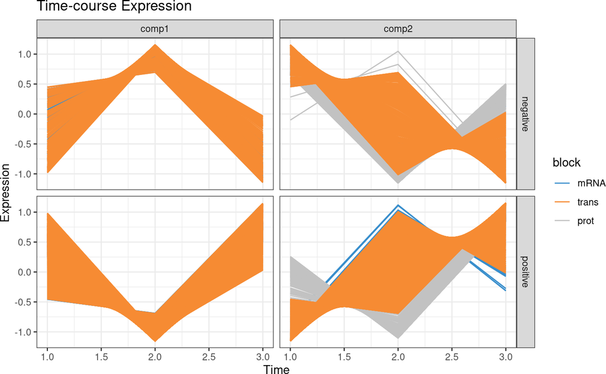

```r
plotLong(block.res, time = c(1,2,3), legend = TRUE)
```

```r
cluster.info <- getCluster(block.res)
summary_cluster(cluster.info)
```

```
##    mRNA trans prot
## 1   202  1213 3213
## -1   75   237   NA
## 2   114   709  446
## -2   57   513  636
```

```r
to.cluster.info.modelled <- getCluster(block.res)
cluster_homo_block(to.cluster.info.modelled)
```

```
## [1] 414.6136
```

```r
summary_cluster(to.cluster.info.modelled)
```

```
##    mRNA trans prot
## 1   202  1213 3213
## -1   75   237   NA
## 2   114   709  446
## -2   57   513  636
```

```r
quick_silhouette(cb.modelled, to.cluster.info.modelled)
```

```
## Silhouette of 7415 units in 4 clusters from silhouette.default(x = cluster, dmatrix = D) :
##  Cluster sizes and average silhouette widths:
##       4628        312       1269       1206
##  0.6199807  0.9135023 -0.1115155  0.4569429
## Individual silhouette widths:
##    Min. 1st Qu.  Median    Mean 3rd Qu.    Max.
## -0.9488  0.3894  0.8696  0.4806  0.8696  0.9486
```

```r
#2 filtered data
data.lmms <- list("mRNA" = mRNA.filter,
                  "trans" = trans.filter,
                  "prot"=prot.filter)

lapply(data.lmms, dim)
```

```
## $mRNA
## [1]   3 446
##
## $trans
## [1]    3 2318
##
## $prot
## [1]    3 4237
```

```r
cb.lmms <- do.call("cbind", data.lmms)
colnames(cb.lmms) <- lapply(data.lmms, colnames) %>% unlist

block.res <- block.pls(data.lmms, ncomp = 3, indY = 1,
                       scale = FALSE, mode = "canonical")
quick_silhouette(cb.lmms, getCluster(block.res))
```

```
## Silhouette of 7001 units in 6 clusters from silhouette.default(x = cluster, dmatrix = D) :
##  Cluster sizes and average silhouette widths:
##       2326         96       1057        933        719       1870
##  0.6462096  0.8777254  0.3302126  0.6417897 -0.9464946 -0.8924162
## Individual silhouette widths:
##     Min.  1st Qu.   Median     Mean  3rd Qu.     Max.
## -0.96617 -0.89740  0.41507  0.02654  0.83613  0.92031
```

```r
to.cluster.info.lmms <- getCluster(block.res)
cluster_homo_block(to.cluster.info.lmms)
```

```
## [1] 248.5
```

```r
summary_cluster(to.cluster.info.lmms)
```

```
##    mRNA trans prot
## 1    88   193 2045
## -1   47    49   NA
## 2    82   593  382
## -2   35   376  522
## 3    95   561   63
## -3   99   546 1225
```

```r
quick_silhouette(cb.lmms, to.cluster.info.lmms)
```

```
## Silhouette of 7001 units in 6 clusters from silhouette.default(x = cluster, dmatrix = D) :
##  Cluster sizes and average silhouette widths:
##       2326         96       1057        933        719       1870
##  0.6462096  0.8777254  0.3302126  0.6417897 -0.9464946 -0.8924162
## Individual silhouette widths:
##     Min.  1st Qu.   Median     Mean  3rd Qu.     Max.
## -0.96617 -0.89740  0.41507  0.02654  0.83613  0.92031
```

Second with the sign of variation:

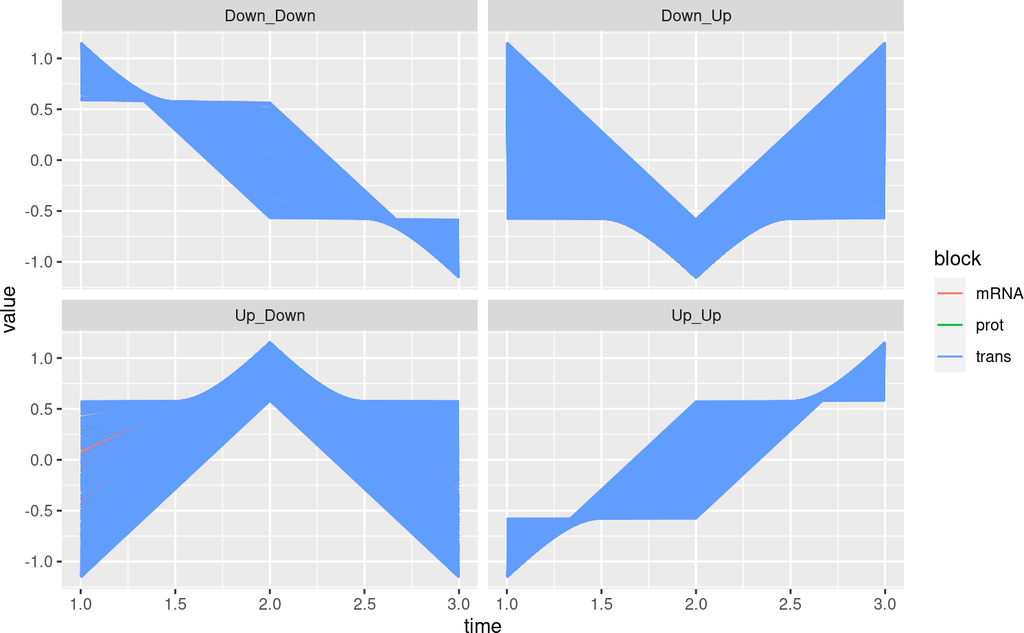

```r
######################################################
# cluster up/down
######################################################

up_down_cluster <- function(x){
    lapply(x, function(x) diff(x) %>%
               sign %>%
               paste(collapse = "_")) %>%
        as.data.frame(check.names = FALSE) %>%
        t %>% as.data.frame(check.names = FALSE) %>%
        rownames_to_column("molecule") %>%
        dplyr::rename(cluster = V1) %>%
        #  pull(cluster) -> zz
        # mutate(cluster = str_split(cluster, "_")) %>%
         # pull(cluster) -> zz
        mutate(cluster = sign_to_updown(cluster))
}

sign_to_updown <- function(zz){
    r <- vector(mode = "character", length = length(zz))
    for(i in 1:length(zz)){
      # print(z)
        z = zz[i] %>% str_split( "_") %>% unlist()
        r[i] <- data.frame("val" = z) %>%
            mutate(conv = ifelse(val == 1, "Up",
                                 ifelse(val == -1, "Down", "0"))) %>%
            pull(conv) %>% paste(collapse = "_")
    }
    return(r)
}

#1. modelled
cluster.info.updown.mean <- imap_dfr(data.mean,
                                     ~{up_down_cluster(.x) %>%
                                             mutate(block = .y)})

# plot
cb.modelled %>% scale %>% as.data.frame() %>% rownames_to_column("time") %>%
    gather(molecule, value, -time) %>%
    left_join(cluster.info.updown.mean) %>%
    mutate(time = factor(time, levels = c("G1","S", "G2/M")) %>% as.numeric()) %>%
    ggplot(aes(x = time, y = value, group =  molecule, col = block)) +
    geom_line() +
    facet_wrap(~cluster)
```

```r
cluster_homo_block(cluster.info.updown.mean)
```

```
## [1] 697.875
```

```r
summary_cluster(cluster.info.updown.mean)
```

```
##           mRNA prot trans
## Down_Down   25    3   274
## Down_Up    241 4279  1521
## Up_Down    107    3   384
## Up_Up       75   10   493
```

```r
quick_silhouette(cb.modelled, cluster.info.updown.mean)
```

```
## Silhouette of 7415 units in 4 clusters from silhouette.default(x = cluster, dmatrix = D) :
##  Cluster sizes and average silhouette widths:
##       302      6041       494       578
## 1.0000000 0.5830463 0.4999795 1.0000000
## Individual silhouette widths:
##    Min. 1st Qu.  Median    Mean 3rd Qu.    Max.
##  0.2960  0.4767  0.7038  0.6270  0.7038  1.0000
```

```r
#2. lmms
cluster.info.updown.lmms <- imap_dfr(data.lmms, ~{up_down_cluster(.x) %>%
        mutate(block = .y)})

# plot
png("./figure/CS1_clusters.png", height =  1500, width = 3000, res = 300)
cb.lmms %>% scale %>% as.data.frame() %>% rownames_to_column("time") %>%
    gather(molecule, value, -time) %>%
  left_join(cluster.info.updown.lmms) %>%
  mutate(cluster = case_when(
    cluster == "Down_Up" ~ "Cluster 1",
    cluster == "Up_Up" ~ "Cluster 2",
    cluster == "Down_Down" ~ "Cluster 3",
    cluster == "Up_Down" ~ "Cluster 4",
  )) %>%
  mutate(block = case_when(
    block == "mRNA" ~ "mRNA",
    block == "trans" ~ "Translation products",
    block == "prot" ~ "Proteins",
  ) %>% factor(., levels = c("mRNA", "Translation products", "Proteins"))) %>%
  mutate( Omics = block) %>%
  mutate(time = time %>% as.numeric()) %>%
  ggplot(aes(x = time, y = value, group =  molecule, col = Omics)) +
  geom_line() +
  facet_wrap(~cluster, nrow = 2) + scale_color_manual(values = color.mixo(1:3)) +
  theme_bw() +
  #theme(legend.position = "bottom") +
  scale_x_continuous(breaks = c(1,2,3), labels = c("G1", "S", "G2/M")) +
  ggtitle("HeLa cell clycling data clusters, scale = TRUE") + xlab("Time") +
    ylab("Scaled expression value")
dev.off()
```

```r
cluster_homo_block(cluster.info.updown.lmms)
```

```
## [1] 630.6591
```

```r
summary_cluster(cluster.info.updown.lmms) %>% rowSums(.)
```

```
## Down_Down   Down_Up   Up_Down     Up_Up
##       958      4443        NA      1444
```

```r
quick_silhouette(cb.lmms, cluster.info.updown.lmms)
```

```
## Silhouette of 7001 units in 4 clusters from silhouette.default(x = cluster, dmatrix = D) :
##  Cluster sizes and average silhouette widths:
##       958      4443       156      1444
## 1.0000000 0.6239606 0.4967742 1.0000000
## Individual silhouette widths:
##    Min. 1st Qu.  Median    Mean 3rd Qu.    Max.
##  0.2508  0.7490  0.7490  0.7501  1.0000  1.0000
```

```r
cluster.info <- cluster.info.updown.lmms
tmp <- summary_cluster(cluster.info.updown.lmms) %>%
    cbind(max = rowSums(., na.rm = TRUE)) %>% arrange(desc(max)) %>%
  dplyr::select(mRNA, trans, prot)
tmp[is.na(tmp)] <- 0
# in %
map2(tmp, colSums(tmp),~.x/.y) %>% as.data.frame() %>%
    `row.names<-`(rownames(tmp))
```

```
##                 mRNA      trans       prot
## Down_Up   0.52242152 0.08067299 0.94949257
## Up_Up     0.18161435 0.53666954 0.02808591
## Down_Down 0.07847534 0.35720449 0.02242152
## Up_Down   0.21748879 0.02545298 0.00000000
```

```r
save(cluster.info, file = "./result/luster_info.rda")
```

We then selected the best modelled/clustering approaches with the silhouette coefficient.

# 4 Network(s) building

In this section we build the networks.

## 4.1 Gene graph

For the Gene network, we used ARACNe (Margolin et al. 2006) algorithm (`minet` R package) We build cluster specific networks and a global network (ALL).

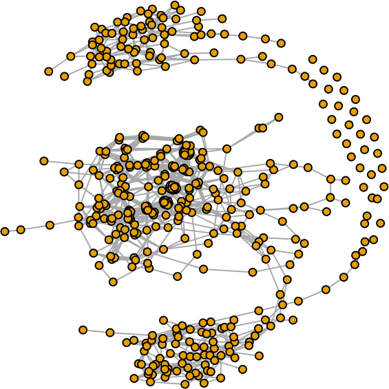

```r
mim <- minet::build.mim(mRNA.fc)
GRN.adg <- aracne(mim)

GRN <- graph_from_adjacency_matrix(GRN.adg, mode = "undirected")
plot(GRN, vertex.label = NA, vertex.size = 4)
```

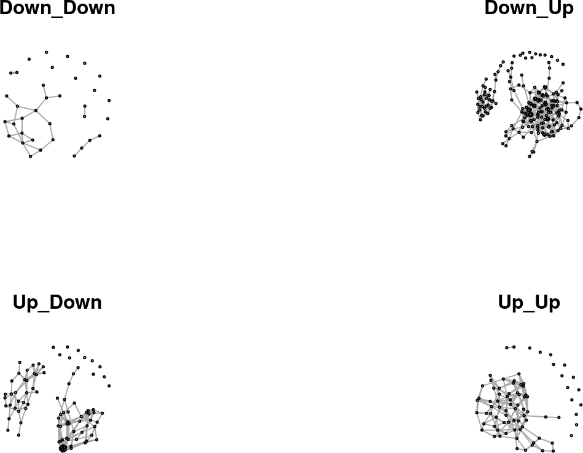

```r
GRN.cluster <- cluster.info %>% filter(block == "mRNA") %>%
    split(.$cluster) %>%
    lapply(function(x)
        dplyr::select(mRNA.fc, intersect(colnames(mRNA.fc), x$molecule)) %>%
               minet::build.mim() %>% aracne %>%
               graph_from_adjacency_matrix(mode = "undirected"))

par(mfrow = c(2,2))
imap(GRN.cluster, ~{
  plot(.x, main = .y,vertex.label = NA, vertex.size = 4,
       vertex.color = "lightblue")
})
```

```r
par(mfrow = c(1,1))

get_stats_graph(GRN) %>% as.data.frame() %>% mutate(cluster = "all")
```

```
##   node.c node.i edge    density cluster
## 1    421     25 4079 0.04110445     all
```

```r
imap_dfr(GRN.cluster, ~get_stats_graph(.x) %>% as.data.frame %>% mutate(cluster = .y))
```

```
##   node.c node.i edge    density   cluster
## 1     25     10   33 0.05546218 Down_Down
## 2    223     10 2338 0.08650289   Down_Up
## 3     86     11  884 0.18986254   Up_Down
## 4     67     14  224 0.06913580     Up_Up
```

```r
GRN.cluster[["all"]] = GRN
imap_dfr(GRN.cluster, ~get_stats_graph(.x) %>% as.data.frame %>%
             mutate(cluster = .y)) %>%
  mutate(cluster = factor(cluster, levels = c("Down_Up", "Up_Up",
                                              "Down_Down", "Up_Down", "all"))) %>%
  arrange(cluster)
```

```
##   node.c node.i edge    density   cluster
## 1    223     10 2338 0.08650289   Down_Up
## 2     67     14  224 0.06913580     Up_Up
## 3     25     10   33 0.05546218 Down_Down
## 4     86     11  884 0.18986254   Up_Down
## 5    421     25 4079 0.04110445       all
```

```r
for(i in names(GRN.cluster)){
    vertex_attr(graph = GRN.cluster[[i]])$name <-
        vertex_attr(graph = GRN.cluster[[i]])$name %>% str_remove("mRNA_")
    vertex_attr(graph = GRN.cluster[[i]])$type <-
        rep("Gene", length(vertex_attr(graph = GRN.cluster[[i]])$name))
}

save(GRN.cluster, file = "./result/GRN.rda")
```

## 4.2 Protein graph

We buid a PPI graph with BioGRID (Chatr-Aryamontri et al. 2015). We filtered the database with the molecules from the experiment.

(This chunk is not evaluated because of the file size limit of github, only the result was uploaded).

```r
# Proteins BIOGRID
biogrid <- read_tsv("data/BIOGRID-ALL-3.5.187.tab3.txt")
biogrid.filtered <- biogrid %>%
    dplyr::select("Official Symbol Interactor A", "Official Symbol Interactor B") %>%
    unique %>% set_names(c("A", "B"))

#write_csv(x = as.data.frame(c(biogrid.filtered$A, biogrid.filtered$B) %>% unique), path = "./paper/uniprot_biogrid_mapping.csv", col_names = FALSE)
# use of annotationDbi
conv.biogrid <- AnnotationDbi::select(org.Hs.eg.db, keytype = "SYMBOL",
                                      keys = c(biogrid.filtered$A, biogrid.filtered$B),
                   columns = c("UNIPROT")) %>%
    unique %>% na.omit

biogrid.filtered <- biogrid.filtered %>%
    left_join(conv.biogrid, by = c("A"="SYMBOL")) %>% dplyr::rename(A.UNIPROT = UNIPROT) %>%
    left_join(conv.biogrid, by = c("B"="SYMBOL")) %>% dplyr::rename(B.UNIPROT = UNIPROT) %>%
    dplyr::select(A.UNIPROT, B.UNIPROT) %>%
    na.omit() %>% unique
save(biogrid.filtered, file = "data/BIOGRID.rda")
```

```r
load("data/BIOGRID.rda")
```

From biogrid we extracted all links between measured molecules and first degree neighbors (PPI_ego).

```r
BIOGRID <- graph_from_data_frame(biogrid.filtered, directed = FALSE) %>% simplify()

prot.nodes.df <- conv %>% filter(UNIPROT %in% str_remove(colnames(prot.modelled), "prot_")) %>%
    filter(UNIPROT %in% V(BIOGRID)$name)
prot.nodes <- prot.nodes.df %>% pull("UNIPROT")

PPI_EGO <- biogrid.filtered %>% filter(A.UNIPROT %in% prot.nodes | B.UNIPROT %in% prot.nodes) %>%
       graph_from_data_frame(directed = FALSE) %>% simplify()
PPI_EGO <- subgraph(BIOGRID, v = V(PPI_EGO)$name)
vcount(PPI_EGO)
```

```
## [1] 23956
```

```r
PPI <- subgraph(BIOGRID, v = prot.nodes[prot.nodes %in% V(BIOGRID)$name])
```

We build PPI subgraph for each cluster. Based on the protein coding gene information (gene -> proteins), we merged Gene networks and PPI networks (cluster-specific sub-networks and global network).

```r
prot.cluster <- cluster.info %>% filter(block == "prot") %>%
    mutate(molecule = molecule %>% str_remove(".*_")) %>%
    left_join(conv, by = c("molecule"="UNIPROT")) %>%
    split(.$cluster)
PPI_cluster <- lapply(prot.cluster, function(x){
    # subgraph(PPI,intersect(V(PPI)$name, x$SYMBOL))
    subgraph(PPI,intersect(V(PPI)$name, x$molecule))
})
PPI_cluster[["all"]] <-  subgraph(PPI, v = intersect(
    lapply(prot.cluster, function(x) x$molecule) %>% unlist(), V(PPI)$name))

imap_dfr(PPI_cluster, ~{vertex_attr(.x) %>% as.data.frame() %>% mutate(cluster = .y)}) %>%
    dplyr::select(name, cluster) %>%
    #unique %>%
    group_by(cluster) %>%
    summarise(N = n()) %>%
    mutate(cluster = factor(cluster,
                            levels = c("Down_Up", "Up_Up", "Down_Down", "Up_Down", "all"))) %>%
    arrange(cluster) %>%
    column_to_rownames("cluster")
```

```
##              N
## Down_Up   1781
## Up_Up       53
## Down_Down   50
## all       1884
```

```r
# stats
imap_dfr(PPI_cluster, ~get_stats_graph(.x) %>%
             as.data.frame %>% mutate(cluster = .y)) %>%
    mutate(cluster = factor(cluster,
                            levels = c("Down_Up", "Up_Up", "Down_Down", "Up_Down", "all"))) %>%
    arrange(cluster)
```

```
##   node.c node.i  edge     density   cluster
## 1   1750     31 18676 0.011782296   Down_Up
## 2     20     33    15 0.010885341     Up_Up
## 3      9     41     6 0.004897959 Down_Down
## 4   1852     32 20227 0.011403292       all
```

```r
detach("package:igraph", unload=TRUE)
library(igraph)
PPI_cluster.ego <- lapply(prot.cluster, function(x){
    make_ego_graph(PPI_EGO, order = 1,
                  # nodes = intersect(V(PPI)$name, x$SYMBOL)) %>%
                  nodes = intersect(V(PPI)$name, x$molecule)) %>%

        do.call(what = "union")
})
PPI_cluster.ego[["all"]] <- PPI_EGO

imap_dfr(PPI_cluster.ego, ~get_stats_graph(.x) %>%
             as.data.frame %>% mutate(cluster = .y))%>%
    mutate(cluster = factor(cluster,
                            levels = c("Down_Up", "Up_Up", "Down_Down", "Up_Down", "all"))) %>%
    arrange(cluster)
```

```
##   node.c node.i    edge     density   cluster
## 1  23761      0 1117076 0.003957324   Down_Up
## 2   5216      0   78895 0.005800796     Up_Up
## 3   4702      0  123743 0.011196383 Down_Down
## 4  23956      0 1450596 0.005055522       all
```

```r
imap_dfr(PPI_cluster.ego, ~{vertex_attr(.x) %>%
        as.data.frame() %>% mutate(cluster = .y) %>%
        mutate(type = ifelse(name %in% (do.call("rbind", prot.cluster) %>%
                                            filter(cluster == .y)  %>%
                                            pull(molecule)), "prot", "ego"))}) %>%
    dplyr::select(name, cluster, type) %>%
    #unique %>%
    group_by(cluster, type) %>%
    summarise(N = n()) %>%
    spread(type, N) %>%
    mutate(cluster = factor(cluster,
                            levels = c("Down_Up", "Up_Up", "Down_Down", "Up_Down", "all"))) %>%
    arrange(cluster) %>%
    column_to_rownames("cluster")
```

```
##             ego prot
## Down_Up   21980 1781
## Up_Up      5163   53
## Down_Down  4652   50
## all       23956   NA
```

We also include the TF (protein) -> gene relationship from TF2DNA and Trrust.

(Again, this R chunk is not evaluated because of the size of the database files).

```r
TFome <- read_tsv("~/work/WORK:analysis/human_tf2DNA/TF2DNA_exp_uniq.txt", col_names = F)
names(TFome) <- c("TF","Target")

TFome2 <- read_tsv("~/Documents/TO2/LOREAL/Data/Proteomic/trrust_rawdata.human.tsv", col_names = F)
colnames(TFome2) <- c("TF", "Target", "Regulation", 'PMID')
TFome2 <- TFome2[,c(1,2)]

TFome <- rbind(TFome, TFome2) %>% unique

TFome %>% dim

conv.ego <- AnnotationDbi::select(org.Hs.eg.db, keytype = "UNIPROT", keys = V(PPI_EGO)$name,
                           columns = c("SYMBOL")) %>%
    unique %>% na.omit

# use TF(uniprot) -> Target(Symbol)
TFome.filtered <- TFome %>% left_join(conv.ego, by = c("TF"="SYMBOL")) %>% na.omit %>%
    dplyr::rename("TF.uniprot" = "UNIPROT") %>%
    dplyr::select(TF.uniprot, Target) %>% # UNIPROT -> SYMBOL
    unique %>%
    set_names(c("Prot", "Gene")) %>%
    mutate(from = Prot, to = Gene)

coding.filtered <- conv.ego %>% set_names(c("Prot", "Gene")) %>%
    mutate(from = Gene, to = Prot)

link_gene_prot = rbind(TFome.filtered, coding.filtered)

merge_GRN_PPI <- function(GRN, PPI, interaction.df){
    # filter interaction
    if(is.null(GRN)){
        return(PPI)
    }
    if(is.null(PPI)){
        return(GRN)
    }
    interaction.graph <- interaction.df %>%
        filter(Gene %in% V(GRN)$name, Prot %in% V(PPI)$name) %>%
        dplyr::select(from,to) %>%
        graph_from_data_frame(directed = FALSE)

    tmp <- igraph::union(GRN, interaction.graph)
    GRN_PPI <- igraph::union(tmp, PPI)
    return(GRN_PPI)
}

GRN_PPI <- list()
GRN_PPI.ego <- list()
for(i in names(GRN.cluster)){
    print(i)
    GRN_PPI[[i]] <- merge_GRN_PPI(GRN = GRN.cluster[[i]],
                                 PPI = PPI_cluster[[i]],
                                 interaction.df = link_gene_prot)
    GRN_PPI.ego[[i]] <- merge_GRN_PPI(GRN = GRN.cluster[[i]],
                                  PPI = PPI_cluster.ego[[i]],
                                  interaction.df = link_gene_prot)

}

save(TFome.filtered, file = "./data/TFome_filtered.rda")
save(GRN_PPI, GRN_PPI.ego, PPI_cluster.ego, PPI_cluster, file = "./result/GRN_PPI.rda")
```

```r
load("./data/TFome_filtered.rda")
load("./result/GRN_PPI.rda")
```

We generate some network statistics.

```r
imap_dfr(PPI_cluster, ~get_stats_graph(.x) %>% as.data.frame %>% mutate(cluster = .y))
```

```
##   node.c node.i  edge     density   cluster
## 1      9     41     6 0.004897959 Down_Down
## 2   1750     31 18676 0.011782296   Down_Up
## 3     20     33    15 0.010885341     Up_Up
## 4   1852     32 20227 0.011403292       all
```

```r
imap_dfr(PPI_cluster.ego, ~get_stats_graph(.x) %>% as.data.frame %>% mutate(cluster = .y))
```

```
##   node.c node.i    edge     density   cluster
## 1   4702      0  123743 0.011196383 Down_Down
## 2  23761      0 1117076 0.003957324   Down_Up
## 3   5216      0   78895 0.005800796     Up_Up
## 4  23956      0 1450596 0.005055522       all
```

```r
imap_dfr(GRN_PPI, ~get_stats_graph(.x) %>% as.data.frame %>% mutate(cluster = .y))
```

```
##   node.c node.i  edge    density   cluster
## 1     43     42    68 0.01904762 Down_Down
## 2   2018     28 30323 0.01449450   Down_Up
## 3     86     11   884 0.18986254   Up_Down
## 4    103     31   429 0.04814274     Up_Up
## 5   2334     28 41991 0.01505949       all
```

```r
imap_dfr(GRN_PPI.ego, ~get_stats_graph(.x) %>% as.data.frame %>% mutate(cluster = .y))
```

```
##   node.c node.i    edge     density   cluster
## 1   4840      0  137853 0.011771864 Down_Down
## 2  24533      0 1378079 0.004579526   Down_Up
## 3     86     11     884 0.189862543   Up_Down
## 4   5408      0  106973 0.007316630     Up_Up
## 5  24943      1 1891625 0.006080653       all
```

```r
# stats
# TF -> genes
TFome.filtered %>% filter((Prot %in% V(PPI_cluster$all)$name) & (Gene %in% V(GRN.cluster$all)$name)) %>%
    unique %>% nrow
```

```
## [1] 16469
```

```r
TFome.filtered %>% filter((Prot %in% V(PPI_cluster$all)$name) & (Gene %in% V(GRN.cluster$all)$name)) %>%
    pull(Prot) %>% unique %>% length
```

```
## [1] 56
```

```r
TFome.filtered %>% filter((Prot %in% V(PPI_cluster$all)$name) & (Gene %in% V(GRN.cluster$all)$name)) %>%
    pull(Gene) %>% unique %>% length
```

```
## [1] 403
```

```r
# genes -> protein coding
coding.filtered %>% filter((Prot %in% V(PPI_cluster$all)$name) & (Gene %in% V(GRN.cluster$all)$name)) %>%
    unique %>% nrow
```

```
## [1] 120
```

```r
coding.filtered %>% filter((Prot %in% V(PPI_cluster$all)$name) & (Gene %in% V(GRN.cluster$all)$name)) %>%
    pull(Prot) %>% unique %>% length
```

```
## [1] 120
```

```r
coding.filtered %>% filter((Prot %in% V(PPI_cluster$all)$name) & (Gene %in% V(GRN.cluster$all)$name)) %>%
    pull(Gene) %>% unique %>% length
```

```
## [1] 120
```

```r
par(mfrow = c(2,2))
imap(PPI_cluster[1:3], ~{
    remove.isolated.nodes(.x, simplify = TRUE) %>%
    plot(main = .y,vertex.label = NA, vertex.size = 4, vertex.color = "orange")
})
```

[figure not shown]

```r
par(mfrow = c(1,1))
```

```r
imap_dfr(GRN_PPI.ego, ~{vertex_attr(.x) %>% as.data.frame() %>% mutate(cluster = .y)}) %>%
    dplyr::select(type, name, cluster) %>%
    #unique %>%
    group_by(type, cluster) %>%
    summarise(N = n()) %>% spread(type, N) %>%
    mutate(cluster = factor(cluster,
                            levels = c("Down_Up", "Up_Up", "Down_Down", "Up_Down", "all"))) %>%
    arrange(cluster) %>%
    column_to_rownames("cluster")
```

```
##           Gene  <NA>
## Down_Up    233 24300
## Up_Up       81  5327
## Down_Down   35  4805
## Up_Down     97    NA
## all        446 24498
```

## 4.3 ORA

We applied a GO terms over representation analysis for each layer.

```r
load("./result/luster_info.rda")
load("./result/GRN_PPI.rda")


list.conv <- cluster.info %>% filter(block %in% c("prot", "trans")) %>% pull(molecule) %>% str_remove('trans_') %>% str_remove("prot_") %>% unique()
conv.tab <- AnnotationDbi::select(org.Hs.eg.db, keytype = "UNIPROT", keys = list.conv,
                                  columns = c("SYMBOL")) %>%
    unique %>% na.omit

# gene
cluster.mRNA <- cluster.info %>% filter(block == "mRNA") %>% mutate(molecule = molecule %>% str_remove("mRNA_")) %>%
    split(.$cluster)
enrich.mRNA <- lapply(cluster.mRNA, function(x) gprofiler2::gost(query = x$molecule, organism = "hsapiens", significant = FALSE))
enrich.mRNA[["all"]] <- gprofiler2::gost(query = (cluster.mRNA %>% lapply(function(x)x$molecule) %>% unlist %>% unname), organism = "hsapiens", significant = FALSE)
#openxlsx::write.xlsx(x = purrr::map(enrich.mRNA, ~.x$result), file = "./analysis/enrich_mRNA.xlsx")

# prot
cluster.prot <- cluster.info %>% filter(block == "prot") %>% mutate(molecule = molecule %>% str_remove("prot_")) %>%
    left_join(conv.tab, by = c("molecule"="UNIPROT")) %>%
    split(.$cluster)
enrich.prot <- lapply(cluster.prot, function(x) gprofiler2::gost(query = x$SYMBOL, organism = "hsapiens", significant = FALSE))
enrich.prot[["all"]] <- gprofiler2::gost(query = (cluster.prot %>% lapply(function(x)x$SYMBOL) %>% unlist %>% unname), organism = "hsapiens", significant = FALSE)
#openxlsx::write.xlsx(x = purrr::map(enrich.prot, ~.x$result), file = "./analysis/enrich_prot.xlsx")


#trans
cluster.trans <- cluster.info %>% filter(block == "trans") %>% mutate(molecule = molecule %>% str_remove("trans_")) %>%
    left_join(conv.tab, by = c("molecule"="UNIPROT")) %>%
    split(.$cluster)
enrich.trans <- lapply(cluster.prot, function(x) gprofiler2::gost(query = x$SYMBOL, organism = "hsapiens", significant = FALSE))
enrich.trans[["all"]] <- gprofiler2::gost(query = (cluster.trans %>% lapply(function(x)x$SYMBOL) %>% unlist %>% unname), organism = "hsapiens", significant = FALSE)
#openxlsx::write.xlsx(x = purrr::map(enrich.trans, ~.x$result), file = "./analysis/enrich_trans.xlsx")


# prot ext
cluster.prot.ext <- imap_dfr(PPI_cluster.ego, ~{V(.x)$name} %>% as.data.frame %>% set_names("molecule") %>% mutate(cluster = .y))
cov.ego <- AnnotationDbi::select(org.Hs.eg.db, keytype = "UNIPROT", keys = as.character(cluster.prot.ext$molecule), columns = c("SYMBOL"))
cluster.prot.ext <- left_join(cluster.prot.ext, cov.ego, by = c("molecule"="UNIPROT")) %>%
    split(.$cluster)
enrich.prot.ext <- lapply(cluster.prot.ext, function(x) gprofiler2::gost(query = x$SYMBOL, organism = "hsapiens", significant = FALSE))
enrich.prot.ext[["all"]] <- gprofiler2::gost(query = (cluster.prot.ext %>% lapply(function(x)x$SYMBOL) %>% unlist %>% unname), organism = "hsapiens", significant = FALSE)
```

We combined the GO terms pvalue to identified shared terms between omic layers.

```r
enr1<- enrich.mRNA$all$result
enr2<- enrich.prot$all$result
combine.pval <- function(enr1, enr2, enr3 = NULL, goterm_map){
    comb <- inner_join(enr1 %>% dplyr::select(p_value, term_id, query_size) %>%
                           dplyr::rename("p_value_1" = "p_value", "query_size_1" = "query_size"),
               enr2 %>% dplyr::select(p_value, term_id, query_size) %>%
                   dplyr::rename("p_value_2" = "p_value", "query_size_2" = "query_size"))
    if(!is.null(enr3)){
        comb <- inner_join(comb, enr3 %>% dplyr::select(p_value, term_id, query_size) %>%
                               dplyr::rename("p_value_3" = "p_value", "query_size_3" = "query_size"))
    }
    comb <- comb %>%
        column_to_rownames("term_id") %>%
        t %>% as.data.frame()
    print(ncol(comb))
    if(ncol(comb) == 0) {
        return(0)
    }
    comb.pvalue <- comb[rownames(comb) %>% str_detect("p_value"),,drop=FALSE]
    comb.weight <- comb[rownames(comb) %>% str_detect("query_size"),,drop=FALSE]

    term_map <- dplyr::select(enr1, c("term_id", "term_name")) %>%
        rbind(dplyr::select(enr2, c("term_id", "term_name"))) %>% unique

    if(!is.null(enr3)){
        term_map <- rbind(term_map, dplyr::select(enr3, c("term_id", "term_name"))) %>% unique
    }

    comb.res <- map2(comb.pvalue, comb.weight, ~{survcomp::combine.test(p = .x, weight = .y, method = "fisher")}) %>%
        as.data.frame(check.names =FALSE) %>% t %>% as.data.frame(check.names =FALSE) %>%
        rownames_to_column("term_id") %>% dplyr::rename("comb.pvalue" = "V1")  %>%
        left_join(term_map , by = c("term_id"="term_id")) %>%
        mutate(adj.pval = p.adjust(.$comb.pvalue, method = "bonf"))


    #survcomp::combine.test(p = comb.pvalue$`GO:0007049`, method = "fisher", weight = comb.weight$`GO:0007049`)
    return(comb.res)
}
#combine.pval(enr1 = enrich.mRNA$all$result, enr2 = enrich.prot$all$result)
enrich.comb.mRNA.prot <- list()
enrich.comb.mRNA.trans <- list()
enrich.comb.mRNA.prot.trans <- list()
enrich.comb.mRNA.prot.ext <- list()


for(i in names(enrich.mRNA)){
    # mRNA - prot
    print(i)
    if(i %in% names(enrich.prot)){
        enrich.comb.mRNA.prot[[i]] <- combine.pval(enr1 = enrich.mRNA[[i]]$result, enr2 = enrich.prot[[i]]$result)
    } else{
        enrich.comb.mRNA.prot[[i]] <- NULL
    }
    # mrna - trans
    if(i %in% names(enrich.trans)){
        enrich.comb.mRNA.trans[[i]] <- combine.pval(enr1 = enrich.mRNA[[i]]$result, enr2 = enrich.trans[[i]]$result)
    } else{
        enrich.comb.mRNA.trans[[i]] <- NULL
    }
    # all
    if((i %in% names(enrich.trans)) & (i %in% names(enrich.prot))){
        enrich.comb.mRNA.prot.trans[[i]] <- combine.pval(enr1 = enrich.mRNA[[i]]$result, enr2 = enrich.prot[[i]]$result, enr3 = enrich.trans[[i]]$result)
    } else{
        enrich.comb.mRNA.prot.trans[[i]] <- NULL
    }
    if(i %in% names(enrich.prot.ext)){
        enrich.comb.mRNA.prot.ext[[i]] <- combine.pval(enr1 = enrich.mRNA[[i]]$result, enr2 = enrich.prot[[i]]$result, enr3 =enrich.prot.ext[[i]]$result )
    } else{
        enrich.comb.mRNA.prot.ext[[i]] <- NULL
    }
}
```

```
## [1] "Down_Down"
## [1] 6578
## [1] 6578
## [1] 6578
## [1] 6578
## [1] "Down_Up"
## [1] 18369
## [1] 18369
## [1] 18369
## [1] 18366
## [1] "Up_Down"
## [1] "Up_Up"
## [1] 8119
## [1] 8119
## [1] 8119
## [1] 8119
## [1] "all"
## [1] 21095
## [1] 20229
## [1] 19931
## [1] 21092
```

```r
enrich.df_mRNA <- imap_dfr(enrich.mRNA, ~.x$result %>% mutate(cluster = .y) %>% filter(significant == TRUE) %>%
                               dplyr::select(term_id, source, p_value, cluster)) %>% filter(source %>% str_detect("GO:")) %>%
    mutate(mode = "raw", type = "mRNA")

enrich.df_prot <- imap_dfr(enrich.prot, ~.x$result %>% mutate(cluster = .y) %>% filter(significant == TRUE) %>%
                               dplyr::select(term_id, source, p_value, cluster)) %>% filter(source %>% str_detect("GO:")) %>% mutate(mode = "raw", type = "prot")

enrich.df_trans <- imap_dfr(enrich.trans, ~.x$result %>% mutate(cluster = .y) %>% filter(significant == TRUE) %>%
                               dplyr::select(term_id, source, p_value, cluster)) %>% filter(source %>% str_detect("GO:"))  %>% mutate(mode = "raw", type = "trans")

enrich.df_prot.ext <- imap_dfr(enrich.prot.ext, ~.x$result %>% mutate(cluster = .y) %>% filter(significant == TRUE) %>%
                               dplyr::select(term_id, source, p_value, cluster)) %>% filter(source %>% str_detect("GO:"))  %>% mutate(mode = "extended", type = "prot")


enrich.df <- do.call("rbind", list(enrich.df_mRNA, enrich.df_prot,enrich.df_prot.ext, enrich.df_trans)) %>%
    mutate(approach = ifelse(cluster == "all", "all", "by_cluster") %>% factor(level = c("by_cluster", "all"))) %>%
    mutate(mode = factor(mode, levels = c("raw", "extended")))
```

production: "table_hela_ora.xlsx

```r
enrich.df.write <-  enrich.df %>% mutate(cluster = case_when(
    cluster == "Down_Up" ~ "Cluster_1",
    cluster == "Up_Up" ~ "Cluster_2",
    cluster == "Down_Down" ~ "Cluster_3",
    cluster == "Up_Down" ~ "Cluster_4",
    cluster == "all" ~ "all")) %>% split(.$type)

enrich.df.write[["comb.p.value"]] <- imap_dfr(enrich.comb.mRNA.prot.trans, ~{.x %>% mutate(cluster = .y) %>%
        filter(adj.pval <= 0.05) %>%
        filter(str_detect(term_id, "GO:")) %>%
        mutate(cluster = case_when(
    cluster == "Down_Up" ~ "Cluster_1",
    cluster == "Up_Up" ~ "Cluster_2",
    cluster == "Down_Down" ~ "Cluster_3",
    cluster == "Up_Down" ~ "Cluster_4",
    cluster == "all" ~ "all"))
    })

#openxlsx::write.xlsx(x = enrich.df.write, file = "./result/table_hela_ora.xlsx")
```

We used the GO -> Gene/Prot relationship to add this GO term layer to the networks.

```r
go.info <- map_dfr(enrich.df$term_id %>% unique, ~get_go_info(.x))

enrich.df <- enrich.df %>% left_join(go.info, by = c("term_id"="name"))
save(enrich.df, file = "./result/enrich_all_filtered.rda")
```

```r
load("./result/enrich_all_filtered.rda")

enrich.df %>% mutate(type = ifelse(mode == "raw", type, "Ext.")) %>%
    dplyr::select(term_id, source, type) %>% unique %>%
    group_by(source, type) %>%
    summarise(N = n()) %>%
    spread(source, N) %>% column_to_rownames('type') %>% .[c("mRNA","trans", "prot", "Ext."),]
```

```
##       GO:BP GO:CC GO:MF
## mRNA    264    74    49
## trans   336   126    64
## prot    344   133    63
## Ext.   1546   402   258
```

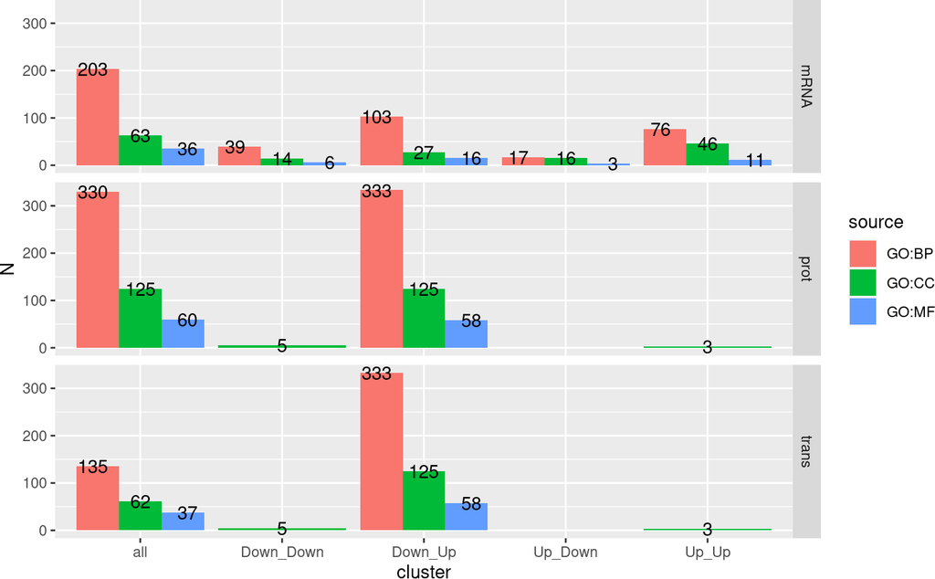

```r
enrich.df %>% filter(mode == "raw") %>%
    #filter(type == "mRNA") %>%
    group_by(type, cluster, source) %>%
    summarise(N = n()) %>%
    ggplot(aes(x = cluster, y = N, fill = source)) + geom_bar(stat = "identity", position = "dodge") +
    geom_text(aes(label = N), vjust=0.5, color="black",position = position_dodge(1)) +
    facet_grid(type~.)
```

```r
tmp.go_terms <- enrich.df$term_id %>% map_df(~get_go_info(.x))

# cluster specific and only visible in cluster (no global)
enrich.df %>% filter(mode == "raw") %>%
    dplyr::select(term_id, source, cluster, approach) %>%
    group_by(term_id, source) %>%
    summarise(N = n()) %>% filter(N == 1) %>% pull(term_id) -> tmp.unique.termi_id
enrich.df %>% filter(mode == "raw") %>%
    filter(term_id %in% tmp.unique.termi_id) %>%
    left_join(tmp.go_terms, by = c('term_id' = 'name')) %>%
    unique() -> tmp.unique.cluster

#tmp.unique.cluster %>% filter(cluster != "all") %>% dplyr::select(cluster, description.x, lab.x) %>% filter(description.x %>% str_detect("BP"))

write_csv(tmp.unique.cluster, path = "./result/cs1_RWR_unique.csv")
```

```r
png("./figure/CS1_goterm_enr.png", height =  1500, width = 2000, res = 300)
enrich.df %>% mutate(approach = ifelse(approach == "by_cluster", "By_Cluster", "Global")) %>%
    mutate(mode = ifelse(mode == "raw", "Raw", "Extended") %>% factor(levels = c("Raw", "Extended"))) %>%
ggplot(aes(x = -log10(p_value), fill = mode)) +
    geom_histogram() +
    theme_bw() +
    scale_fill_manual(values = c("lightgrey", "black")) +
    theme(legend.position = "none") +
    facet_grid(approach~mode) +
    ylab("Number of GO terms")
dev.off()
```

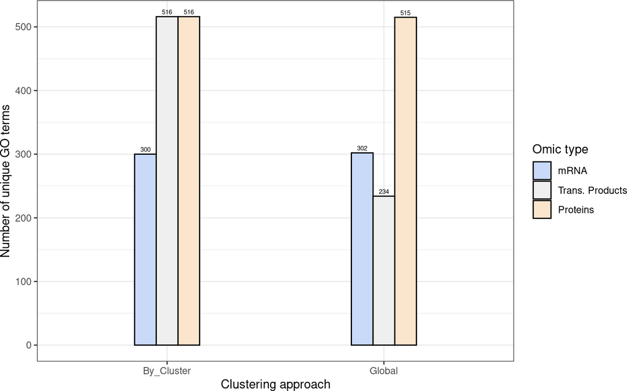

```r
#png("./figure//CS1_goterm_enr_2.png", height =  1500, width = 2000, res = 300)
enrich.df %>% mutate(approach = ifelse(approach == "by_cluster", "By_Cluster", "Global")) %>%
    mutate(mode = ifelse(mode == "raw", "Raw", "Extended") %>% factor(levels = c("Raw", "Extended"))) %>%
    dplyr::select(term_id, source, type, mode, approach) %>% unique %>%
    group_by(source, mode, approach, type) %>%
    summarise(N = n()) %>%
    filter(mode == "Raw") %>%
    group_by(type, mode, approach) %>%
    summarise(N = sum(N)) %>%
    mutate(type = case_when(
        type == "mRNA" ~ "mRNA",
        type == "prot" ~ "Proteins",
        type == "trans" ~ "Trans. Products"
    ) %>% factor(levels = c("mRNA",  "Trans. Products", "Proteins"))) %>%
    ggplot(aes(x = approach, y = N, fill = type)) +
    geom_bar(stat = "identity", position = "dodge", width = 0.3, col = "black") +
    geom_text(aes(label = N), vjust=-0.5, color="black",position = position_dodge(0.3), size = 2) +
#    facet_grid(.~mode)  +
    theme_bw() + labs(fill = "Omic type",
                      x = "Clustering approach",
                      y = "Number of unique GO terms") +
    scale_fill_manual(values = c("#c9daf8", "#efefef", "#fce5cd"))
```

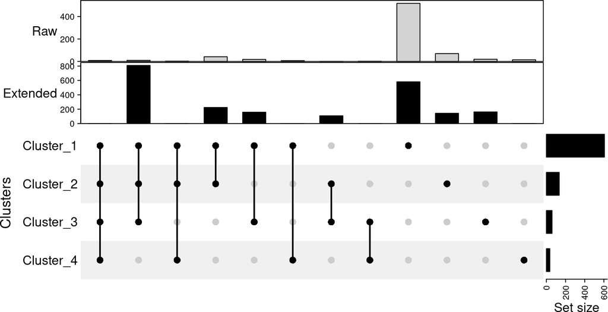

```r
#dev.off()

set.count.raw <-  enrich.df %>% filter(mode == "raw", cluster != "all") %>% split(.$cluster) %>% lapply(function(x) pull(x, term_id))
set.count.raw <- set.count.raw[c("Down_Up", "Up_Up", "Down_Down", "Up_Down")]
names(set.count.raw) <- paste0("Cluster_", 1:4)
set.count.raw <- set.count.raw %>% make_comb_mat(min_set_size = 0)

set.count.ext <-  enrich.df %>% filter(mode == "extended", cluster != "all") %>% split(.$cluster) %>% lapply(function(x) pull(x, term_id))
set.count.ext[["Up_Down"]] <- c(1)
set.count.ext <- set.count.ext[c("Down_Up", "Up_Up", "Down_Down", "Up_Down")]
names(set.count.ext) <- paste0("Cluster_", 1:4)
set.count.ext <- set.count.ext %>% make_comb_mat(min_set_size = 0)

set.count.raw <- set.count.raw[union(comb_name(set.count.raw), comb_name(set.count.ext))]
set.count.ext <- set.count.ext[union(comb_name(set.count.raw), comb_name(set.count.ext))]

top_ha = HeatmapAnnotation(
    "Raw" = anno_barplot(comb_size(set.count.raw), gp = gpar(fill = "lightgrey"), height = unit(2, "cm")),
    "Extended" = anno_barplot(comb_size(set.count.ext), gp = gpar(fill = "black"), height = unit(2, "cm")),
    annotation_name_side = "left", annotation_name_rot = 0)

#png("./figure//CS1_goterm_enr_3.png", height =  1300, width = 4000, res = 300)
UpSet(set.count.raw, top_annotation = top_ha,heigh = unit(5, "cm"), row_title = "Clusters")
```

```r
#dev.off()
```

```r
# all signif GO
all_mol <- c(lapply(cluster.mRNA, function(x){x$molecule}) %>% base::unlist() %>% unname,
             lapply(cluster.prot, function(x){x$SYMBOL}) %>% base::unlist() %>% unname,
             lapply(cluster.trans, function(x){x$SYMBOL}) %>% base::unlist() %>% unname,
             lapply(cluster.prot.ext, function(x){x$SYMBOL}) %>% base::unlist() %>% unname) %>%
    unique %>% na.omit()
length(all_mol)
```

```
## [1] 13699
```

```r
goterm_map <- gprofiler2::gconvert(query = all_mol, organism = "hsapiens", target = "GO")
save(goterm_map, file = "./result/goterm_map.rda")


signif_goterm_map <- goterm_map %>% filter(target %in% enrich.df$term_id) %>%
    dplyr::select(input, target) %>% unique %>% na.omit()

signif_goterm_map$input %>% unique %>% length
```

```
## [1] 13441
```

```r
signif_goterm_map$target %>% unique %>% length
```

```
## [1] 1926
```

```r
signif_goterm_map.all <- rbind(signif_goterm_map, left_join(signif_goterm_map, conv.tab, by = c("input" = "SYMBOL")) %>%
                                   na.omit() %>% dplyr::select("UNIPROT", "target") %>% set_names("input", "target")) %>%
    unique


GRN_PPI.ego.GO <- lapply(GRN_PPI.ego, add_go_term_layer)

imap_dfr(GRN_PPI.ego.GO, ~{vertex_attr(.x) %>% as.data.frame() %>% mutate(cluster = .y)}) %>%
    dplyr::select(type, name, cluster) %>%
    #unique %>%
    group_by(type, cluster) %>%
    summarise(N = n()) %>% spread(type, N) %>%
    mutate(cluster = factor(cluster, levels = c("Down_Up", "Up_Up", "Down_Down", "Up_Down", "all"))) %>%
    arrange(cluster) %>%
    column_to_rownames("cluster")
```

```
##           Gene   GO  <NA>
## Down_Up    233 1588 23761
## Up_Up       81 1332  5216
## Down_Down   35 1341  4702
## Up_Down     97  449    NA
## all        446 1605 23956
```

```r
##############################
# for annotation full graph
##############################

## unkown function
table(all_mol %in% unique(goterm_map$input))
```

```
##
## FALSE  TRUE
##   122 13577
```

```r
table(unique(lapply(cluster.mRNA, function(x){x$molecule}) %>% base::unlist() %>% unname) %in% unique(goterm_map$input))
```

```
##
## FALSE  TRUE
##     6   440
```

```r
table(unique(lapply(cluster.prot, function(x){x$SYMBOL}) %>% base::unlist() %>% unname) %in% unique(goterm_map$input))
```

```
##
## FALSE  TRUE
##     6  1998
```

```r
table(unique(lapply(cluster.trans, function(x){x$SYMBOL}) %>% base::unlist() %>% unname) %in% unique(goterm_map$input))
```

```
##
## FALSE  TRUE
##     4  1062
```

```r
table(unique(lapply(cluster.prot.ext, function(x){x$SYMBOL}) %>% base::unlist() %>% unname) %in% unique(goterm_map$input))
```

```
##
## FALSE  TRUE
##   117 13417
```

```r
unknown_seeds <- all_mol[!(all_mol %in% unique(goterm_map$input))] %>% unique
unknown_seeds_nodes <- c(do.call("rbind", cluster.mRNA) %>% mutate(seed = molecule) %>% filter(molecule %in% unknown_seeds) %>% na.omit() %>% pull(seed),
                         do.call("rbind", cluster.prot) %>% mutate(seed = molecule) %>% filter(SYMBOL %in% unknown_seeds) %>%  na.omit() %>% pull(seed)
                         #do.call("rbind", cluster.trans) %>% mutate(seed = molecule) %>% filter(SYMBOL %in% unknown_seeds) %>% na.omit() %>% pull(seed)
                         #do.call("rbind", cluster.prot.ext) %>% mutate(seed = molecule) %>% mutate(type = "ext") %>% filter(SYMBOL %in% unknown_seeds) %>% na.omit() %>% pull(seed)
                         ) %>% unique


save(unknown_seeds, unknown_seeds_nodes, file ="./result/unknown_seeds.rda")
```

## 4.4 Metabolite

Finaly, we included a metabolite layer from Kegg (Kanehisa et al. 2016) with Gene <-> KO and KO <-> GO interactions.

```r
load("./data/reaction_mapformula_df.rda")

# kegg ko <-> rn <-> hsa
ko_reaction.list <- read_tsv("~/work/KEGGBD/ko/ko_reaction.list", col_names = c("ko", "rn"))
ko_enzyme.list <- read_tsv("~/work/KEGGBD/ko/ko_enzyme.list", col_names = c("ko", "ec"))
ko_gene.list <- read_tsv("~/work/KEGGBD/ko/ko_genes.list", col_names = c("ko", "gn"))

ko_reaction_enzyme_gene <- ko_reaction.list %>% full_join(ko_enzyme.list) %>% full_join(ko_gene.list)


tmp <- ko_reaction_enzyme_gene %>% filter(str_detect(gn, "hsa:")) %>%
    mutate(rn = str_remove(rn,"^rn:"), gn = str_remove(gn,"^hsa:")) %>%
    left_join(reaction_mapformula_df)

ENTREZID_lookup <- AnnotationDbi::select(org.Hs.eg.db, keytype = "ENTREZID", keys = tmp$gn,columns = c("UNIPROT")) %>%
    unique %>% na.omit

metab_uniprot <- tmp %>% left_join(ENTREZID_lookup, by = c("gn"="ENTREZID"))

METAB.graph <- igraph::graph_from_data_frame(metab_uniprot %>% dplyr::select(p1,p2) %>% unique %>% na.omit(), directed = FALSE)
interaction_met_prot.df <- metab_uniprot %>% dplyr::select(UNIPROT,p1,p2) %>% gather(p, met, -UNIPROT) %>% dplyr::select(-p) %>% unique %>% na.omit()
```

```r
################
# Add metabo layer
################

load(file = ".//result/GRN_PPI_GO.rda")


graph = GRN_PPI.ego.GO$all

interaction_met_prot.df %>% filter(UNIPROT %in% V(graph)$name) %>% pull(met) %>% unique %>% length
interaction_met_prot.df %>% filter(UNIPROT %in% V(graph)$name) %>% pull(UNIPROT) %>% unique %>% length

FULL_graph <- lapply(GRN_PPI.ego.GO, add_metabo_layer)



## add GO
#ko_go.list <- read_tsv(file = "~/work/KEGGBD/ko/ko_go.list", col_names = c("ko", "go"))
# ko2go <- ko_reaction_enzyme_gene %>% full_join(ko_go.list) %>%
#     mutate(rn = str_remove(rn, "rn:")) %>%
#     left_join(reaction_mapformula_df) %>% dplyr::select(go, p1, p2) %>%
#     gather(p, cpd, -c(go)) %>%
#     dplyr::select(go, cpd) %>%
#     unique %>%
#     mutate(go = str_replace(go, "go:", "GO:"))
#save(ko2go, file = "./ko2go.rda")
load("./data/ko2go.rda")

#ko2go$cpd %in% (lapply(FULL_graph, function(x) V(x)$name) %>% unlist() %>% unname)
graph <- FULL_graph$all
#ko2go %>% filter(cpd %in% tmp$name & go %in% tmp$name)


FULL_graph <- lapply(FULL_graph, add_go_metabo_edges)
save(FULL_graph, file = "./result/graph_w_metabo.rda")


imap_dfr(FULL_graph, ~{vertex_attr(.x) %>% as.data.frame() %>% mutate(cluster = .y)}) %>%
    dplyr::select(type, name, cluster) %>%
    #unique %>%
    group_by(type, cluster) %>%
    summarise(N = n()) %>% spread(type, N) %>%
    mutate(cluster = factor(cluster, levels = c("Down_Up", "Up_Up", "Down_Down", "Up_Down", "all"))) %>%
    arrange(cluster) %>%
    column_to_rownames("cluster")
```

and we cleaned the graph (remove duplicate links, correct layer names, …)

```r
# list prot only
prot_only <- lapply(PPI_cluster, function(x)V(x)$name) %>% unlist %>% unname
prot_ego <- setdiff(lapply(PPI_cluster.ego, function(x)V(x)$name) %>% unlist %>% unname, prot_only)
prot_ego <- map_dfr(PPI_cluster.ego, ~vertex_attr(.x)) %>% pull(name) %>% setdiff(prot_only)

prot_only <- imap_dfr(PPI_cluster, ~ vertex_attr(.x) %>% as.data.frame %>% mutate(cluster = .y))

gene_only <-  lapply(GRN.cluster, function(x)V(x)$name) %>% unlist %>% unname

metab_only <- map_dfr(FULL_graph, ~vertex_attr(.x) %>% as.data.frame) %>% filter(type == "Metabolite") %>% pull(name) %>% as.character()

go_only <-  map_dfr(GRN_PPI.ego.GO, ~vertex_attr(.x) %>% as.data.frame) %>% filter(type == "GO") %>% pull(name) %>% as.character()

FINAL <- purrr::imap(FULL_graph, ~reformate_graphs(graph = .x,cluster = .y ))

FINAL_GO_ANNOT <- list("BP" = FINAL_GOBP,
                       "CC" = FINAL_GOCC,
                       "MF" = FINAL_GOMF)
FINAL_GO_ANNOT <- purrr::map(FINAL_GO_ANNOT, ~reformate_graphs(graph = .x,cluster = "all" ))

FINAL_GO_ANNOT_short <- list("BP" = FINAL_GOBP_short,
                       "CC" = FINAL_GOCC_short,
                       "MF" = FINAL_GOMF_short)
FINAL_GO_ANNOT_short <- purrr::map(FINAL_GO_ANNOT_short, ~reformate_graphs(graph = .x,cluster = "all" ))

save(FINAL, FINAL_GO_ANNOT, FINAL_GO_ANNOT_short, file = './final/FINAL.rda')

imap_dfr(FINAL, ~{vertex_attr(.x) %>% as.data.frame() %>% mutate(cluster = .y)}) %>%
    dplyr::select(type, name, cluster) %>%
    #unique %>%
    group_by(type, cluster) %>%
    summarise(N = n()) %>% spread(type, N) %>%
    mutate(cluster = factor(cluster, levels = c("Down_Up", "Up_Up", "Down_Down", "Up_Down", "all"))) %>%
    arrange(cluster) %>%
    column_to_rownames("cluster")
```

# 5 Random Walk

## 5.1 RWR for Multi-omics mechanisms

```r
load("./result/FINAL.rda")
load("./result/unknown_seeds.rda")
load("./result/enrich_all_filtered.rda")
list_go <- enrich.df %>% filter(mode == "raw", source == "GO:BP") %>% pull(term_id) %>% unique
list_go <- enrich.df  %>% pull(term_id) %>% unique
va.all <- vertex_attr(FINAL$all) %>% as.data.frame()

lapply(FINAL, function(x) table(V(x)$name %in% list_go))
```

```
## $Down_Down
##
## FALSE  TRUE
##  5489  1238
##
## $Down_Up
##
## FALSE  TRUE
## 26233  1461
##
## $Up_Down
##
## FALSE  TRUE
##   121   417
##
## $Up_Up
##
## FALSE  TRUE
##  6087  1237
##
## $all
##
## FALSE  TRUE
## 26655  1474
```

```r
lapply(FINAL, function(x) table(list_go %in% V(x)$name))
```

```
## $Down_Down
##
## FALSE  TRUE
##  1071  1238
##
## $Down_Up
##
## FALSE  TRUE
##   848  1461
##
## $Up_Down
##
## FALSE  TRUE
##  1892   417
##
## $Up_Up
##
## FALSE  TRUE
##  1072  1237
##
## $all
##
## FALSE  TRUE
##   835  1474
```

```r
set.seed(1)
# RWR_go_mechanisms <- parallel::mclapply(FINAL, function(graph) {
#     parallel::mclapply(list_go, function(go) {homo_network_RWR(graph, seed = go, k = 25)}, mc.cores = 20)},
#     mc.cores = 4)
# Sys.time()
load("./result/RWR_res_mechanisms.rda")
```

```r
RWR_go_mechanisms <- lapply(RWR_go_mechanisms, function(x) `names<-`(x, list_go))
graph <- RWR_go_mechanisms$all$`GO:0005515`
length(RWR_go_mechanisms$all)  # nb go term tested

RWR_go_mechanisms_annot <- lapply(names(RWR_go_mechanisms), function(x){
    imap_dfr(RWR_go_mechanisms[[x]], ~{ mechanisms_annot(.x, .y)}) %>%
        mutate(CLUSTER = x)}) %>%
    do.call(what = "rbind")
write.csv(RWR_go_mechanisms_annot, file = "./result/RWR_meca.csv")
```

```r
RWR_go_mechanisms_annot_tmp <- RWR_go_mechanisms_annot %>%
    group_by(CLUSTER, seed, type) %>%
    summarise(N=n()) %>% spread(type, N)
RWR_go_mechanisms_annot_tmp[is.na(RWR_go_mechanisms_annot_tmp)] <- 0


good_go_list.df <- enrich.df %>% filter(mode == "raw") %>% dplyr::select(term_id, source, description) %>%
    unique %>% filter(source == "GO:BP")
#
# RWR_go_mechanisms_annot_tmp %>% filter(Metabolite>0, Gene >0, Prot>0) %>%
#     left_join(map_dfr(.$seed %>% unique, ~get_go_info(.x)), by = c("seed"="name"))
#
# RWR_go_mechanisms_annot_tmp %>% filter(Metabolite>0, Gene >0, Prot>0) %>%
#     left_join(good_go_list.df, by = c("seed"="term_id")) %>%
#     na.omit


# exported result along with seed <-> molecule (va)
tmp_meca <- RWR_go_mechanisms_annot_tmp %>%
    left_join(enrich.df %>% dplyr::select(term_id, source, mode, description) %>% unique, by = c("seed"="term_id"))
#write.csv(tmp_meca, file = ".//RWR_meca_stats.csv")
#tmp_meca <- read.csv(".//RWR_meca_stats.csv")

# gene and protein and metabolite
tmp_meca %>%
    filter(mode == "raw") %>%  # only based enriched GO // not extended
    filter(Metabolite>0, Gene >0, Prot>0) %>%
    dplyr::select(seed, description, source, CLUSTER) %>%
    group_by(source, CLUSTER) %>%
    summarise(N=n()) %>% spread(source, N) %>%
    mutate(CLUSTER = factor(CLUSTER, levels = c("Down_Up", "Up_Up", "Down_Down", "Up_Down", "all"))) %>%
    arrange(CLUSTER)

tmp_meca %>%
    filter(mode == "raw") %>%
    filter(Gene >0, Prot>0)  %>%
    mutate(approach = ifelse(CLUSTER == "all", "all", "by_cluster"))  %>%
    ungroup() %>%
    dplyr::select(approach, seed, source) %>% unique %>%
    group_by(approach, source) %>% summarise(N=n()) %>% spread(source, N)


tmp_meca %>%
    filter(mode == "raw") %>%  # only based enriched GO // not extended
    filter(Metabolite>0, Gene >0, Prot>0) %>%
    dplyr::select(seed, description, source, CLUSTER) %>%
    group_by(CLUSTER, seed, description, source) %>%
    summarise(N = n()) %>%
    spread(CLUSTER, N) %>%
    mutate(SUM = sum(all, Down_Down, Down_Up, Up_Up, na.rm = TRUE)) %>%
    filter(SUM == 1)

### PLOT FIGURE
#tmp_meca %>% filter(seed == 'GO:0007088')
plot.graph.tmp <- RWR_go_mechanisms$all[["GO:0007088"]]
l <- layout_nicely(plot.graph.tmp)
l <- norm_coords(l, ymin=-1, ymax=1, xmin=-1, xmax=1)
seed.plot = "GO:0007088"
# plot.graph.tmp <- RWR_go_mechanisms$all[["GO:0034968"]]
vertex_attr(plot.graph.tmp)<- vertex_attr(plot.graph.tmp) %>% as.data.frame() %>% left_join(va.all) %>%
    mutate(color = ifelse(name == seed.plot, "red", color))
vertex_attr(plot.graph.tmp)<- vertex_attr(plot.graph.tmp) %>%
    mutate(color = ifelse(type == "Prot.ego", "orange", color),
           frame.color = ifelse(type %in% c("Prot.ego", "Metabolite"), "red", "darkgrey"),
           size = ifelse(type %in% c("Prot.ego", "Metabolite"), 5,6),
           size = ifelse(name == seed.plot, 8, size))

#png("./figure/cs1_rwr_meca.png", height =  3000, width = 3500, res = 300)
plot(plot.graph.tmp, layout=l)
legend("bottomleft",
       legend = c("SEED", "Genes", "Proteins", "Metabolites", "GO terms", "Ext. neighbours"),
       col = c("red", "lightblue", "orange", "green", "lightgrey", "red"),
       pch = c(19, 19, 19, 19, 19, 1),
       pt.cex = c(1.5, 1, 1, 1, 1, 1.5),
       cex = 1.3,
       box.col="white"
)
title("Regulation of mitotic nuclear division")
#dev.off()
```

```r
### PLOT FIGURE
tmp_meca %>% filter(seed == 'GO:0007088')
plot.graph.tmp <- RWR_go_mechanisms$all[["GO:0007088"]]
l <- layout_nicely(plot.graph.tmp)
l <- norm_coords(l, ymin=-1, ymax=1, xmin=-1, xmax=1)
seed.plot = "GO:0007088"
# plot.graph.tmp <- RWR_go_mechanisms$all[["GO:0034968"]]
#vertex_attr(plot.graph.tmp) <-
vertex_attr(plot.graph.tmp)<- vertex_attr(plot.graph.tmp) %>% as.data.frame() %>% left_join(va.all) %>%
    mutate(color = ifelse(name == seed.plot, "red", color))
vertex_attr(plot.graph.tmp)<- vertex_attr(plot.graph.tmp) %>%
    mutate(color = ifelse(type == "Prot.ego", "orange", color),
           frame.color = ifelse(type %in% c("Prot.ego", "Metabolite"), "red", "darkgrey"),
           size = ifelse(type %in% c("Prot.ego", "Metabolite"), 5,6),
           size = ifelse(name == seed.plot, 8, size))

#png("./figure/cs1_rwr_meca.png", height =  3000, width = 3500, res = 300)
plot(plot.graph.tmp, layout=l)
legend("bottomleft",
       legend = c("SEED", "Genes", "Proteins", "Metabolites", "GO terms", "Ext. neighbours"),
       col = c("red", "lightblue", "orange", "green", "lightgrey", "red"),
       pch = c(19, 19, 19, 19, 19, 1),
       pt.cex = c(1.5, 1, 1, 1, 1, 1.5),
       cex = 1.3,
       box.col="white"
)
title("Regulation of mitotic nuclear division")
#dev.off()

# stat
stat_table <- function(list_g){
    res <- imap_dfr(list_g, ~.x %>%
                        vertex_attr %>%
                        mutate(type = factor(type, levels = levels(va.all$type))) %>%
                        pull(type) %>% table %>% as.data.frame() %>%
                        column_to_rownames(".") %>% set_names(.y) %>%
                        t %>% as.data.frame() %>% rownames_to_column("seed"))
    return(res)
}
stat_rwr_cluster <- imap_dfr(good_go_cluster, ~stat_table(.x) %>% mutate(cluster=.y))
stat_rwr_all <- stat_table(good_go_all) %>% mutate(cluster="all")

stat_rwr_cluster %>%
    arrange(desc(Gene, Prot, Prot.ego, Metabolite, go_term)) %>%
    filter(Metabolite >0) %>%
    mutate(seed = factor(seed, levels = unique(.$seed))) %>%
    gather(type, value, -c(seed, cluster)) %>% left_join(dplyr::select(va.all, c(type, color, lab)) %>% unique) %>%
    ggplot(aes(x=seed, y=value, fill = lab)) + geom_bar(stat = "identity") +
    facet_grid(~cluster,scales = "free_x", space = "free") +
    scale_fill_manual(values = dplyr::select(va.all, c(type, color, lab)) %>% unique %>% arrange(type) %>% pull(color)) +
    theme_bw() +
    theme(axis.text.x = element_text(angle = 90, hjust = 1)) +
    xlab(label = "Seed (GO terms)") + ylab("Number of molecules") +
    guides(fill = guide_legend("Type of molecule")) +
    ggtitle("Random Walk Result with a multi-omics hits")

stat_rwr_all %>%
    arrange(desc(Gene, Prot, Prot.ego, Metabolite, go_term)) %>%
    filter(Metabolite >0) %>%
    mutate(seed = factor(seed, levels = unique(.$seed))) %>%
    gather(type, value, -c(seed, cluster)) %>% left_join(dplyr::select(va.all, c(type, color, lab)) %>% unique) %>%
    ggplot(aes(x=seed, y=value, fill = lab)) + geom_bar(stat = "identity") +
    facet_grid(~cluster,scales = "free_x", space = "free") +
    scale_fill_manual(values = dplyr::select(va.all, c(type, color, lab)) %>% unique %>% arrange(type) %>% pull(color)) +
    theme_bw() +
    theme(axis.text.x = element_text(angle = 90, hjust = 1)) +
    xlab(label = "Seed (GO terms)") + ylab("Number of molecules") +
    guides(fill = guide_legend("Type of molecule")) +
    ggtitle("Random Walk Result with a multi-omics hits")

# list of molecule without go
graph <- FINAL$all
with_go_annotation <- function(graph, node){
    ego <- make_ego_graph(graph = graph, nodes = node, order = 1)[[1]]
    va <- vertex_attr(ego) %>% as.data.frame() %>% na.omit()
    return(any(va$type == "GO"))
}
```

## 5.2 RWR for annotation

SEED = unknown

/home/antoine/Documents/TO2/netOmics-case-studies/HeLa_Cell_Cycling

```r
######################################
# 2. Get annotation SEED = unknown
######################################


# get annotation
# nodes <- V(graph)$name
# nodes_with_go <- lapply(nodes, function(x)with_go_annotation(graph = graph, node = x))
load("./result/unknown_seeds.rda")


# 1. monoplex
purrr::map(FINAL_GO_ANNOT_short,  ~table(unknown_seeds_nodes %in% V(.x)$name))

unknown_seeds_nodes[purrr::map(FINAL,  ~as.numeric(unknown_seeds_nodes %in% V(.x)$name)) %>% as.data.frame() %>%
    rowSums() > 0]

res <- as.list(unknown_seeds_nodes)
names(res) = unknown_seeds_nodes

RES_aggregation <- parallel::mclapply(FINAL_GO_ANNOT_short, function(graph){
    parallel::mclapply(res, function(seed){
        find_annotation(graph = graph, seed = seed)
    }, mc.cores = 8)
}, mc.cores = 8)

# 2. heterogeity: split
load(file = "./result/goterm_map.rda")
interaction.df = goterm_map %>% dplyr::select(input, target) %>% unique


# RES_het <- parallel::mclapply(FINAL_GO_ANNOT_short, function(graph){
#     parallel::mclapply(res, function(seed){
#         find_annot_RWR_het(graph = graph, seed = seed, interaction.df = interaction.df)
#     }, mc.cores = 8)
# }, mc.cores = 8)

## explore result
load("./result/RWR_find_annotations.rda")

# load("./RES_het.rda")
# load("./RWR_RES_aggregation.rda")

#short_path <- lapply(FINAL_GO_ANNOT_short, function(x) igraph::shortest.paths(x))

tmp.aggregation <- imap_dfr(RES_aggregation$BP, ~annot_RWR_res(.x) %>% mutate(type = "BP", seed = .y)) %>% na.omit() %>% rbind(
imap_dfr(RES_aggregation$CC, ~annot_RWR_res(.x) %>% mutate(type = "CC", seed = .y)) %>% na.omit()) %>% rbind(
imap_dfr(RES_aggregation$MF, ~annot_RWR_res(.x) %>% mutate(type = "MF", seed = .y)) %>% na.omit()) %>%
    left_join(map_dfr(.$NodeNames %>% unique, ~get_go_info(.x)), by = c("NodeNames"="name"))  %>%
    mutate(mode = "monoplex")


# RES_RWR_het <- RES_het$BP$KIAA1671
# RES_RWR_het <- RES_het$BP$CCDC18


# het_BP <- imap_dfr(RES_het$BP, ~filtre_res_het(.x) %>% mutate(type = "BP", seed = .y)) %>% na.omit() %>% mutate(mode = "heterogeneous")
# het_MF <- imap_dfr(RES_het$MF, ~filtre_res_het(.x) %>% mutate(type = "MF", seed = .y)) %>% na.omit() %>% mutate(mode = "heterogeneous")
# het_CC <- imap_dfr(RES_het$CC, ~filtre_res_het(.x) %>% mutate(type = "CC", seed = .y)) %>% na.omit() %>% mutate(mode = "heterogeneous")

# tmp.heterogeneous <- rbind(het_BP, het_MF, het_CC) %>% left_join(map_dfr(.$NodeNames %>% unique, ~get_go_info(.x)), by = c("NodeNames"="name"))
#
# tmp.melt <- rbind(tmp.aggregation, tmp.heterogeneous %>% dplyr::select(-"composition")) %>%
#     dplyr::select(lab, seed, type, mode, position, description) %>%
#     spread(mode, position) %>%
#     rename("lab" = "go") %>%
#     dplyr::select(seed, type, go, description, monoplex, heterogeneous)
# write_csv(tmp.melt, path = "./result/RWR_annotations.csv")
```

## 5.3 RWR for intersection between clusters

```r
#####################
# 3. in between nodes
#####################
load("./result/luster_info.rda")
load("./result/FINAL.rda")
#load("./unknown_seeds.rda")

graph <- FINAL$all
SEEDS <- cluster.info %>% filter(block %in% c("mRNA", "prot")) %>%
    mutate(molecule = molecule %>% str_remove("mRNA_") %>% str_remove("prot_")) %>%
    filter(molecule %in% V(graph)$name) %>%
    #pull(block) %>% table
    pull(molecule)

res <- as.list(SEEDS)
names(res) = SEEDS
for(i in SEEDS){
    print(i)
    #res[[i]] <- find_annotation(FINAL_GO_ANNOT$BP, i)
    res[[i]] <- in_between(FINAL$all, i, k = 10)
}
# save(res, file = "./RWR_between.rda")
load("./result/RWR_between.rda")

graph <- res$Q8NI77
seed_name <- "Q8NI77"
va.all <- vertex_attr(FINAL$all) %>% as.data.frame()

detect_intersection(res$ANLN, seed_name = "ANLN")
res_between_intersection <- imap(res, ~detect_intersection(.x, seed_name = .y))
res_between_intersection %>% lapply(is.null) %>% unlist %>% table
res_between_intersection_with_go <-  res_between_intersection[res_between_intersection %>% lapply(nrow) %>% unlist %>% subset(.>0) %>% names] %>%
    imap_dfr(~{.x %>% mutate(seed = .y)}) %>% dplyr::select(seed, name, description)

write_csv(x = res_between_intersection_with_go, path = "./result/RWR_cluster_intersection.csv")

# != go terms
res_between_intersection_with_go %>% filter(name %>% str_detect("GO:")) %>% group_by(name, description) %>% summarise(N = n()) %>% arrange(desc(N)) %>%
    mutate(source = description %>% str_extract("....$")) %>% split(.$source)

# seed with != cluster and GO terms
res_between_intersection_with_go %>% filter(name %>% str_detect("GO:")) %>% pull(seed) %>% unique %>% length

# example
res_between_intersection_with_go %>% filter(seed %in% (res_between_intersection_with_go %>% filter(name == "GO:0051301") %>% pull(seed)))
va.all %>% filter(name %in% c("PIMREG", "H6PD", "SETD1B"))
res_between_intersection[["PIMREG"]]
igraph::make_ego_graph(FINAL$all, nodes = "PIMREG", order = 1) %>% .[[1]] %>% vertex_attr() %>% as.data.frame() %>%
    left_join(cluster.info %>% mutate(molecule = molecule %>% str_remove("mRNA_")),by = "molecule")

res_between_intersection_with_go %>% filter(seed %in% (res_between_intersection_with_go %>% filter(name == "GO:0007275") %>% pull(seed)))


# openxlsx::write.xlsx(x = list("mechanism" = RWR_go_mechanisms_annot, "prediction" = tmp.heterogeneous, "cluster" = res_between_intersection_with_go),
#                      file = "./results/table_hela_rwr.xlsx")

### PLOT FIGURE
plot.graph.tmp <- res$PIMREG
l <- layout_nicely(plot.graph.tmp)
l <- norm_coords(l, ymin=-1, ymax=1, xmin=-1, xmax=1)
seed.plot = "PIMREG"
plot.graph.tmp <- res$PIMREG
vertex_attr(plot.graph.tmp)<- vertex_attr(plot.graph.tmp) %>% as.data.frame() %>% left_join(va.all) %>%
    dplyr::select(-cluster) %>% left_join(cluster.info %>% filter(block == "mRNA") %>% mutate(molecule = molecule %>% str_remove("mRNA_")), by = c("name"="molecule")) %>%
    mutate(color = ifelse(name == seed.plot, "red", color)) %>%
    mutate(cluster = case_when(
        cluster == "Down_Up" ~ "Cluster 1",
        cluster == "Up_Up" ~ "Cluster 2",
        cluster == "Down_Down" ~ "Cluster 3",
        cluster == "Up_Down" ~ "Cluster 4",
    ))

vertex_attr(plot.graph.tmp)<- vertex_attr(plot.graph.tmp) %>%
    mutate(color = ifelse(type == "Prot.ego", "orange", color),
           #frame.color = ifelse(type %in% c("Prot.ego", "Metabolite"), "red", "darkgrey"),
           size = ifelse(type %in% c("Prot.ego", "Metabolite"), 5,6),
           size = ifelse(name == seed.plot, 8, size),
           frame.color = case_when(
               cluster == "Cluster 1" ~ "darkgreen",
               cluster == "Cluster 2" ~ "orange",
               cluster == "Cluster 3" ~ "purple",
               cluster == "Cluster 4" ~ "orange",
               TRUE ~ "grey"))


#png("./figure/cs1_rwr_cluster.png", height =  3000, width = 3500, res = 300)
plot(plot.graph.tmp, layout=l)
legend("topleft",
       legend = c("SEED", "Genes", "GO terms"),
       col = c("red", "lightblue", "lightgrey"),
       pch = c(19, 19, 19),
       pt.cex = c(1.5, 1, 1),
       cex = 1.3,
       box.col="white"
)
legend("bottomright",
       legend = paste0("Cluster ", 1:2),
       col = c("darkgreen", "orange"),
       pch = c(1),
       cex = 1.3,
       box.col="white")
title("PIMREG\n(PICALM Interacting Mitotic Regulator)")
#dev.off()

load("./result/data_filtered.rda")
tmp.no.model<- mRNA.fc %>%
    rownames_to_column("sample") %>%
    mutate(time = sample %>% str_remove("_Rep.")) %>%
    gather(name, value, -c(time, sample)) %>%
    mutate(name = name %>% str_remove("mRNA_")) %>%
    filter(name %in% vertex_attr(plot.graph.tmp)$name) %>%
    mutate(time = case_when(
        time == "G1" ~ 1,
        time == "S" ~ 2,
        time == "G2/M" ~3)) %>% left_join( vertex_attr(plot.graph.tmp)) %>%
    dplyr::select(time, name, value, cluster) %>%
    arrange(cluster)
order.name <- tmp.no.model$name %>% unique


tmp.no.model<- tmp.no.model %>% mutate(name = factor(name, levels = order.name))
# long clustering
tmp.model <- mRNA.filter %>%  rownames_to_column("time") %>%
    gather(name, value, -time) %>%
    mutate(name = name %>% str_remove("mRNA_")) %>%
    left_join(vertex_attr(plot.graph.tmp)) %>%
    filter(!is.na(cluster)) %>%
    dplyr::select(time, name, value, cluster) %>%
    mutate(time = as.numeric(time)) %>%
    mutate(name = factor(name, levels = order.name))


#png("./figure/cs1_rwr_cluster_dyn.png", height =  2500, width = 2000, res = 300)
ggplot(tmp.model, aes(x=time, y=value, group = name, col = cluster)) + geom_line() +
    geom_point(data = tmp.no.model) +
    #facet_wrap(name~., dir = "v", ncol = 1, scales = "free") +
    facet_grid(name~., scales = "free") +

    theme_bw() +
    scale_color_manual(values = c("darkgreen", "orange")) +
    labs(x = "Time", y = "Expression value", col = "Cluster") +
    theme(legend.position = "top")
#dev.off()
```

Aviner, Ranen, Anjana Shenoy, Orna Elroy-Stein, and Tamar Geiger. 2015. “Uncovering Hidden Layers of Cell Cycle Regulation Through Integrative Multi-Omic Analysis.” *PLoS Genet* 11 (10): e1005554.

Chatr-Aryamontri, Andrew, Bobby-Joe Breitkreutz, Rose Oughtred, Lorrie Boucher, Sven Heinicke, Daici Chen, Chris Stark, et al. 2015. “The Biogrid Interaction Database: 2015 Update.” *Nucleic Acids Research* 43 (D1): D470–D478.

Kanehisa, Minoru, Yoko Sato, Masayuki Kawashima, Miho Furumichi, and Mao Tanabe. 2016. “KEGG as a Reference Resource for Gene and Protein Annotation.” *Nucleic Acids Research* 44 (D1): D457–D462.

Margolin, Adam A, Ilya Nemenman, Katia Basso, Chris Wiggins, Gustavo Stolovitzky, Riccardo Dalla Favera, and Andrea Califano. 2006. “ARACNE: An Algorithm for the Reconstruction of Gene Regulatory Networks in a Mammalian Cellular Context.” In *BMC Bioinformatics*, 7:S7. S1. Springer.